# SPSP R Workshop

Template for graphing in ggplot2:

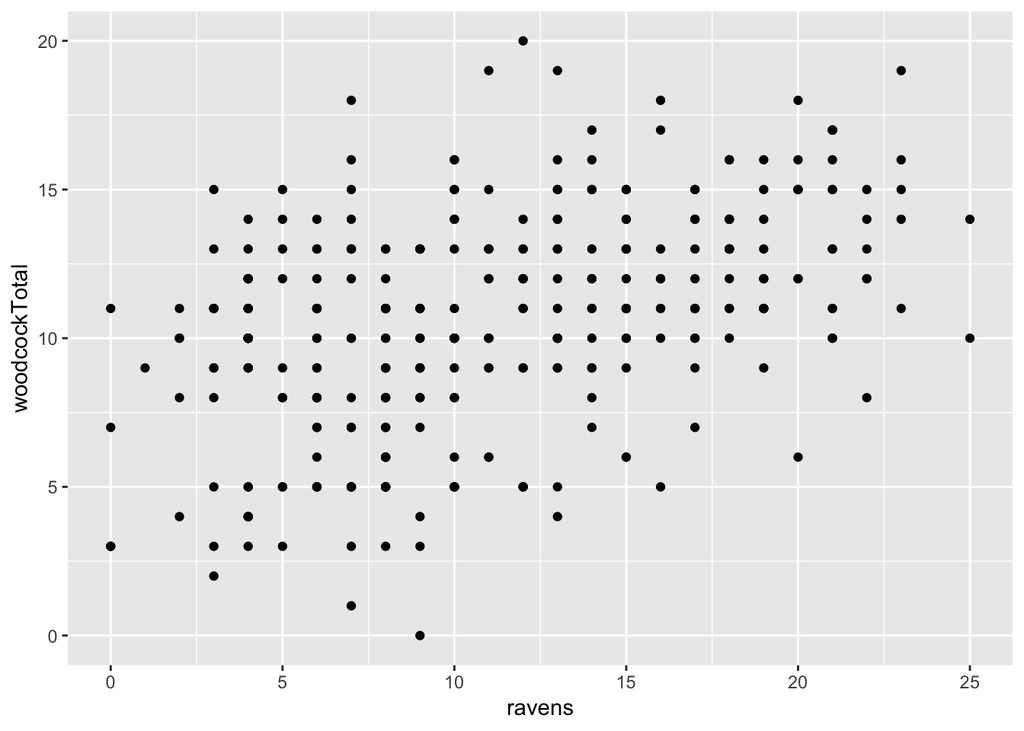

```r
ggplot(data = ma_data) +
  geom_point(mapping = aes(x = ravens, y = woodcockTotal))
```

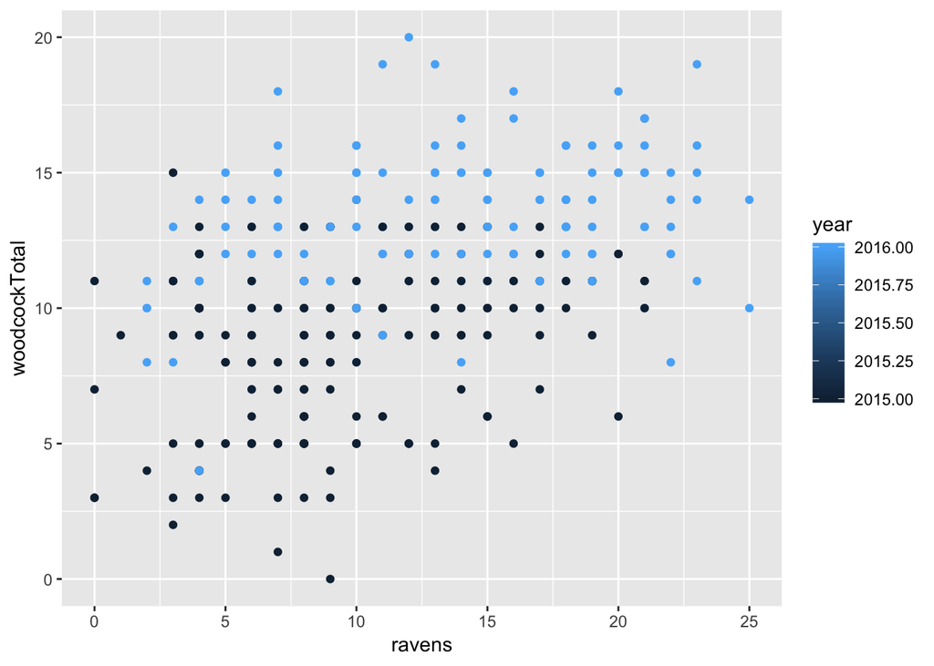

```r
ggplot(data = ma_data) +
  geom_point(mapping = aes(x = ravens, y = woodcockTotal, color = year))
```

```r
#ggplot assigned each level of *color* to each unique value of `year`. This is called *scaling*.

#but - if `year` is a binary variable (2015 or 2016), why does the legend display a scale?
str(ma_data)
```

```
## Classes 'tbl_df', 'tbl' and 'data.frame':    328 obs. of  14 variables:
##  $ subid            : chr  "S1-02-03" "S1-02-03" "S1-02-08" "S1-02-08" ...
##  $ class_num        : chr  "S1_02" "S1_02" "S1_02" "S1_02" ...
##  $ grade            : chr  "first grade" "first grade" "first grade" "first grade" ...
##  $ group            : chr  "CNTL" "CNTL" "CNTL" "CNTL" ...
##  $ year             : int  2015 2016 2015 2016 2015 2016 2015 2016 2015 2016 ...
##  $ ravens           : int  3 15 4 12 5 10 8 18 8 8 ...
##  $ gonogo           : num  0.815 0.708 0.762 0.708 0.431 ...
##  $ swm              : num  1.83 2.12 1.62 1.38 1.5 ...
##  $ pvAvg            : num  0 0.36 0 0.36 0.09 NA 0 0.91 0 0.27 ...
##  $ arithmeticTotal  : int  0 12 0 4 8 NA 4 16 3 8 ...
##  $ arithmeticAverage: num  0 0.25 0 0.08 0.17 NA 0.08 0.33 0.06 0.17 ...
##  $ woodcockTotal    : int  2 15 3 9 9 10 5 13 6 9 ...
##  $ ef               : num  2.65 2.83 2.39 2.08 1.93 ...
##  $ ravens_centered  : num  -8.088 3.912 -7.088 0.912 -6.088 ...
```

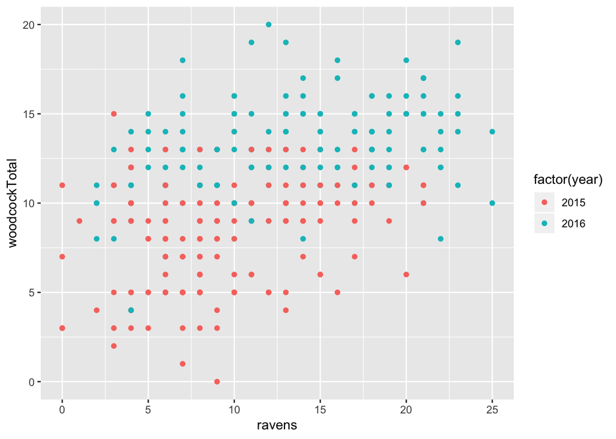

```r
#we need to tell ggplot that `year` is a factor
ggplot(data = ma_data) +
  geom_point(mapping = aes(x = ravens, y = woodcockTotal, color = factor(year)))
```

> **Exercise 7.** Options for *aesthetics* include color, shape, size, and alpha. Create a scatter plot to visualize the relationship between `gonogo` and `swm`. Add an aesthetic to visualize the effect of `grade`. Choose any aesthetic you’d like or play around with a few. What do they do? How might you use more than one aesthetic?

Do we need to specify that `grade` is a factor?

> ProTip: We could also make separate graphs for each level of `grade` using `facet_wrap` by passing a formula (data structure) to `facet_wrap`. I use this often!

Here’s how:

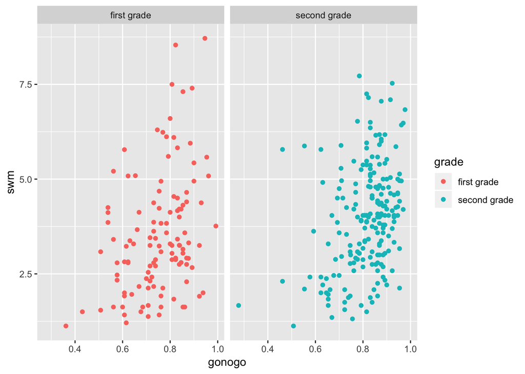

```r
ggplot(data = ma_data) +
  geom_point(mapping = aes(x = gonogo, y = swm, color = grade)) +
  facet_wrap(~ grade)
```

Maybe we’d prefer a line graph instead of a scatterplot to describe the relationship between `ravens` and `woodcockTotal`. In this case, we’d use a different *geom* (e.g., point, line, smooth, boxplot, bar).

Let’s make the same plot, using the smooth *geom* which fits a smoothed line to the data.

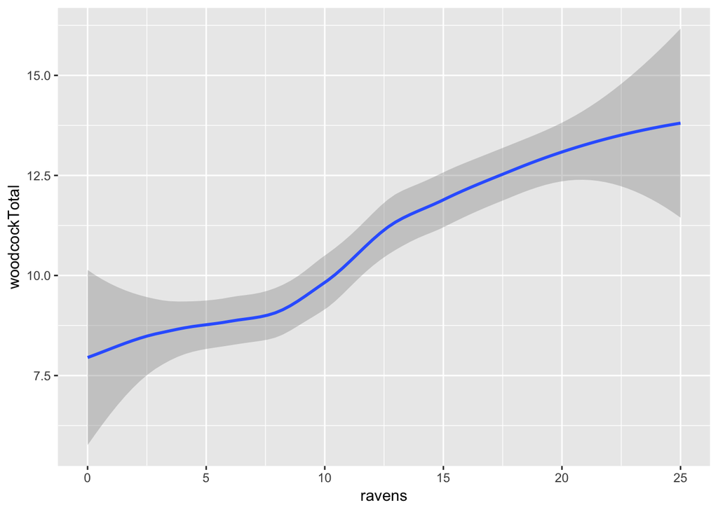

```r
ggplot(data = ma_data) +
  geom_smooth(mapping = aes(x = ravens, y = woodcockTotal))
```

```r
#loess is the default function for geom_smooth()
# from http://www.statisticshowto.com/lowess-smoothing/: LOWESS (Locally Weighted Scatterplot Smoothing), sometimes called LOESS (locally weighted smoothing), is a popular tool used in regression analysis that creates a smooth line through a timeplot or scatter plot to help you to see relationship between variables and foresee trends.
```

We can add aesthetics to help visualize the data:

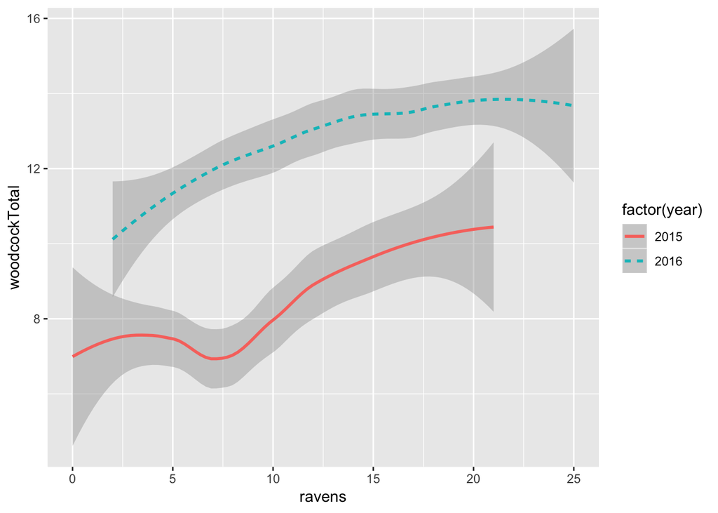

```r
ggplot(data = ma_data) +
  geom_smooth(mapping = aes(x = ravens, y = woodcockTotal, linetype = factor(year), color = factor(year)))
```

We can also layer multiple geoms in the same plot!

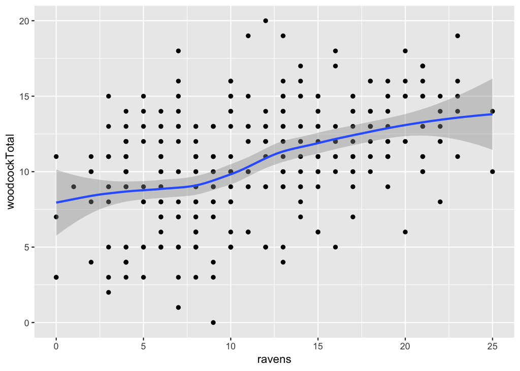

```r
ggplot(data = ma_data) +
  geom_point(mapping = aes(x = ravens, y = woodcockTotal)) +
  geom_smooth(mapping = aes(x = ravens, y = woodcockTotal))
```

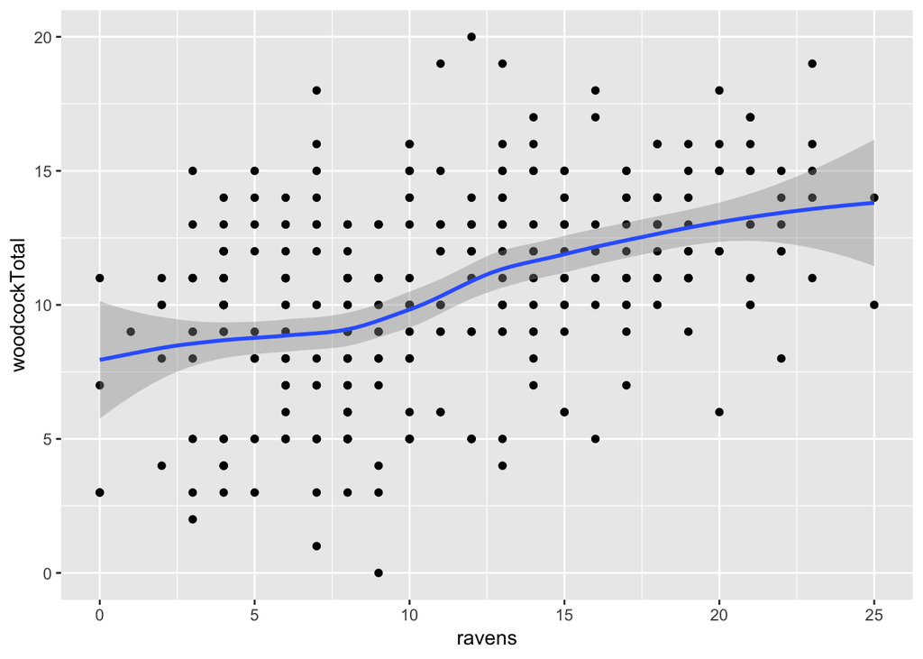

```r
#we could also have used global mappings
ggplot(data = ma_data, mapping = aes(x = ravens, y = woodcockTotal)) +
  geom_point() +
  geom_smooth()
```

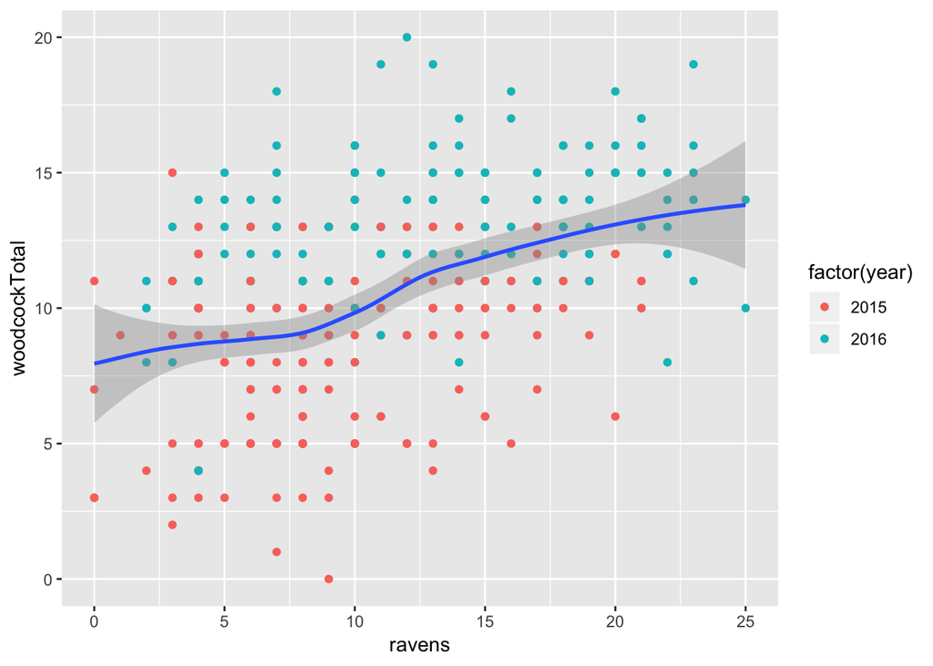

```r
#finally, we can add an *aesthetic* to only one part of the graph
ggplot(data = ma_data, mapping = aes(x = ravens, y = woodcockTotal)) +
  geom_point(mapping = aes(color = factor(year))) +
  geom_smooth()
```

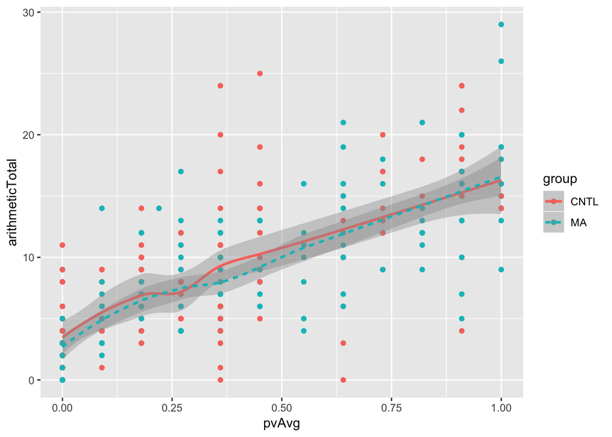

```r
ggplot(data = ma_data, mapping = aes(x = pvAvg, y = arithmeticTotal)) +
  geom_point(mapping = aes(color = group)) +
  geom_smooth(mapping = aes(color = group, linetype = group))
```

First, we’ll need to use the skills we’ve previously acquired to create a table of means that we’ll then plot. We’ll then use the argument stat = “identity” to map the mean value onto the y aesthetic.

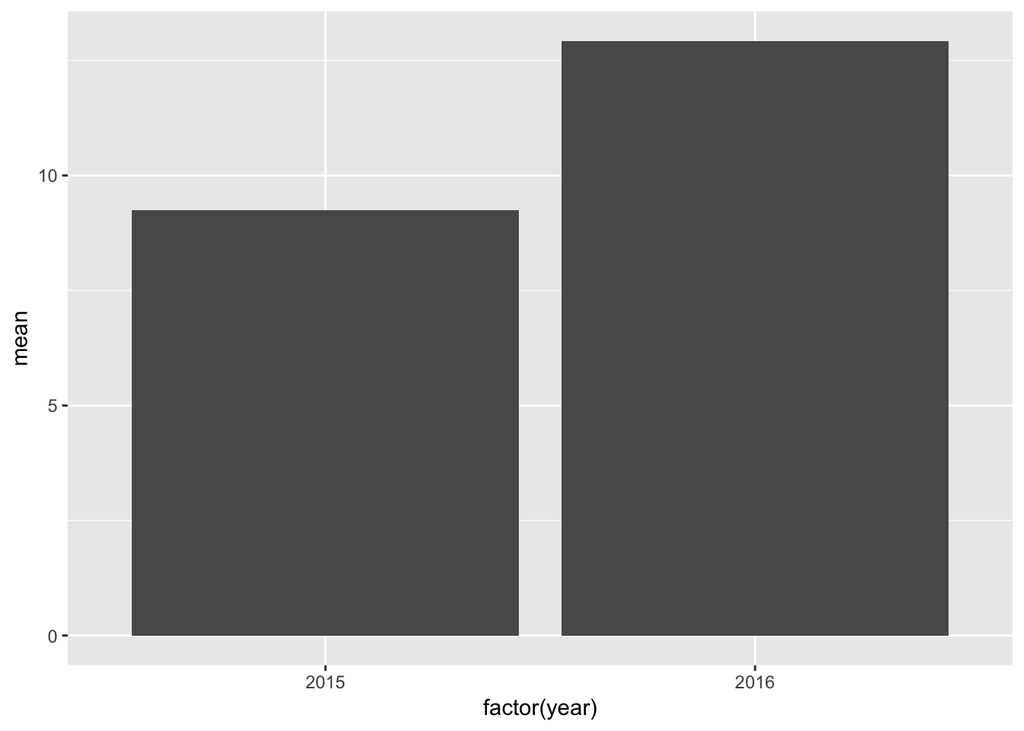

```r
plot.data <- ma_data %>%
  group_by(year) %>%
  summarise(mean = mean(ravens))

ggplot(plot.data, aes(x=factor(year), y=mean)) +
  geom_bar(stat="identity")
```

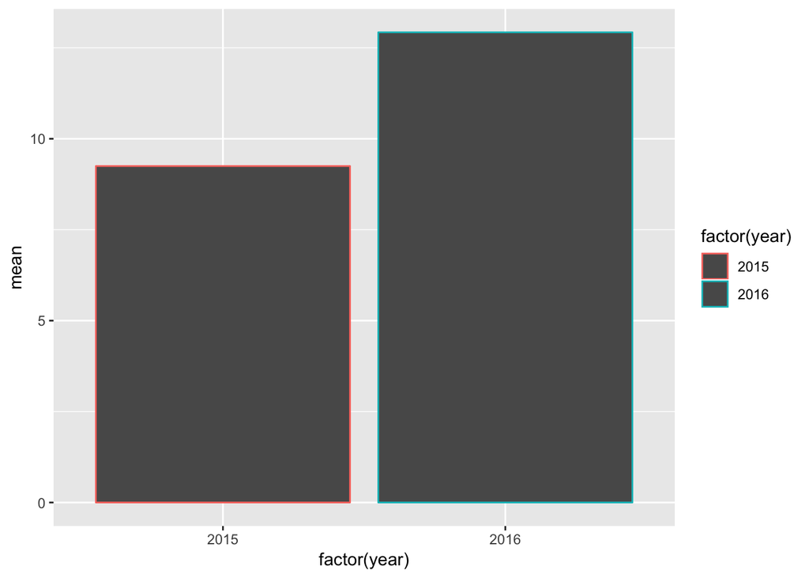

```r
#more options:
ggplot(plot.data, aes(x=factor(year), y=mean, color = factor(year))) +
  geom_bar(stat="identity")
```

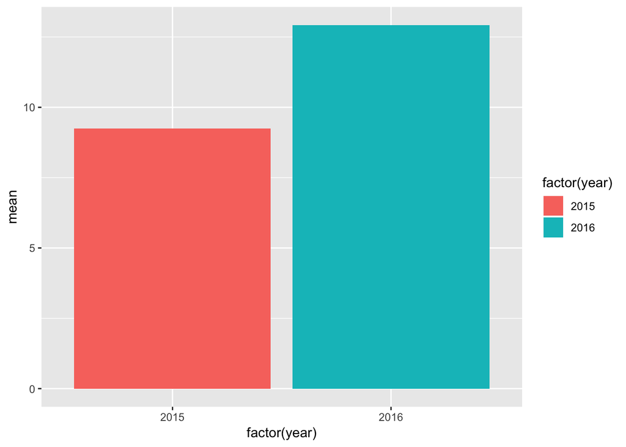

```r
ggplot(plot.data, aes(x=factor(year), y=mean, fill = factor(year))) +
  geom_bar(stat="identity")
```

> **Exercise 9.** Earlier we looked at whether the difference in pre- and post-intervention scores (i.e., `year`) on `ravens` differs for children in the control (`CNTL`) versus experimental (`MA`) groups. Let’s plot these differences. Create one graph for the intervention group and another for the control group.

Hint: See `facet_wrap` above.

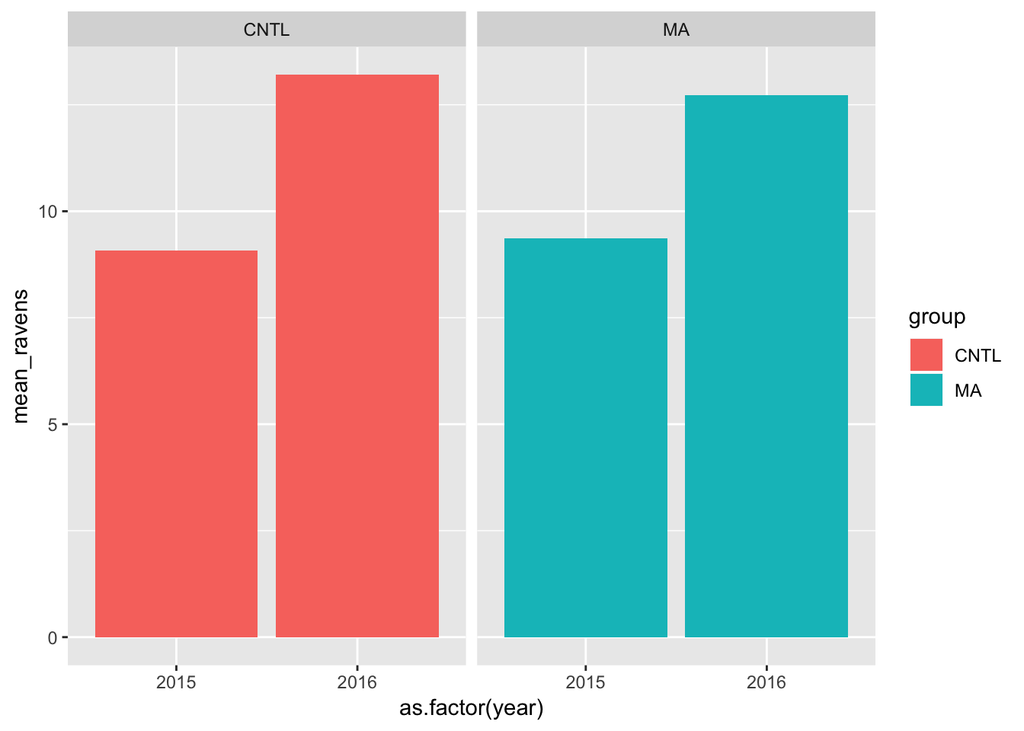

```r
plot.data <- ma_data %>%
  group_by(year, group) %>%
  summarise(mean_ravens = mean(ravens),
            sd = sd(ravens))

ggplot(plot.data, aes(x = as.factor(year), y = mean_ravens, fill = group)) +
  geom_bar(stat = "identity") +
  facet_wrap(~ group)
```